# Analysis of Flight Data from the USA

Joanne White

3/16/2020

This report looks at flight data for the USA for the first two weeks of July 2015. In this report we will explore, investigate and visualise the data.

This will help answer questions posed such as investigate.

- which airlines have the most delays?
- what are the busiest routes
- is there a relationship between ‘distance between airports’ and flying time?
- can we predict flying time based on distance?

#### 1. Import data

Three files imported contained data for airline, airports and flight data for the first two weeks in July 2015.

#### 2. Explore the data

To look at the data, we looked at the head of the 3 files which displays the first 6 records of each file.

###### Display first 6 records from Airline.csv

```
##   IATA_CODE                AIRLINE
## 1        UA  United Air Lines Inc.
## 2        AA American Airlines Inc.
## 3        US        US Airways Inc.
## 4        F9 Frontier Airlines Inc.
## 5        B6        JetBlue Airways
## 6        OO  Skywest Airlines Inc.
```

This shows that airline.csv has 2 columns ITAT_code and what airline it represents.

###### Display first 6 records from Airport.csv

```
##   IATA_CODE                             AIRPORT        CITY STATE COUNTRY
## 1       ABE Lehigh Valley International Airport   Allentown    PA     USA
## 2       ABI            Abilene Regional Airport     Abilene    TX     USA
## 3       ABQ   Albuquerque International Sunport Albuquerque    NM     USA
## 4       ABR           Aberdeen Regional Airport    Aberdeen    SD     USA
## 5       ABY  Southwest Georgia Regional Airport      Albany    GA     USA
## 6       ACK          Nantucket Memorial Airport   Nantucket    MA     USA
##   LATITUDE  LONGITUDE
## 1 40.65236  -75.44040
## 2 32.41132  -99.68190
## 3 35.04022 -106.60919
## 4 45.44906  -98.42183
## 5 31.53552  -84.19447
## 6 41.25305  -70.06018
```

The airport.csv 7 columns that relate to the airport including location (state) and its exact location in the form of Latitude and longitude. We decided to remove LATITUDE anad LONGDITUDE from the file.

###### Display first 6 records from airrecords.csv

```
##   YEAR MONTH DAY DAY_OF_WEEK AIRLINE FLIGHT_NUMBER TAIL_NUMBER ORIGIN_AIRPORT
## 1 2015     7   1           3      NK           298      N624NK            LAS
## 2 2015     7   1           3      AA          1965      N507AY            SFO
## 3 2015     7   1           3      DL          2020       N3759            LAX
## 4 2015     7   1           3      NK           612      N629NK            LAS
## 5 2015     7   1           3      UA          1044      N39418            ANC
## 6 2015     7   1           3      AA           260      N3BHAA            LAX
##   DESTINATION_AIRPORT SCHEDULED_DEPARTURE DEPARTURE_TIME DEPARTURE_DELAY
## 1                 IAH                   3             41              38
## 2                 CLT                   5           2400              -5
## 3                 MEM                   5           2400              -5
## 4                 MSP                   5             53              48
## 5                 ORD                   8             17               9
## 6                 MIA                  10              5              -5
##   TAXI_OUT WHEELS_OFF SCHEDULED_TIME ELAPSED_TIME AIR_TIME DISTANCE WHEELS_ON
```

[output cut: 27 more lines]

In the airrecords.csv we can see there are 31 columns. We decided to remove columns COUNTRY (All flights in USA), WHEELS_ON, WHEELS_OFF,TAXI_IN, TAXI_OUT and ELASPSED_TIME,

### Summary statistics for the three csv files.

###### Display Statistics for each column for airlines file.

```
##    IATA_CODE                         AIRLINE
##  AA     :1   Alaska Airlines Inc.        :1
##  AS     :1   American Airlines Inc.      :1
##  B6     :1   American Eagle Airlines Inc.:1
##  DL     :1   Atlantic Southeast Airlines :1
##  EV     :1   Delta Air Lines Inc.        :1
##  F9     :1   Frontier Airlines Inc.      :1
##  (Other):8   (Other)                     :8
```

###### Display Statistics for each column for airports file.

```
##    IATA_CODE                              AIRPORT            CITY
##  ABE    :  1   Aberdeen Regional Airport      :  1   Albany    :  2
##  ABI    :  1   Abilene Regional Airport       :  1   Charleston:  2
##  ABQ    :  1   Abraham Lincoln Capital Airport:  1   Chicago   :  2
##  ABR    :  1   Adak Airport                   :  1   Columbia  :  2
##  ABY    :  1   Akron-Canton Regional Airport  :  1   Columbus  :  2
##  ACK    :  1   Albany International Airport   :  1   Houston   :  2
##  (Other):316   (Other)                        :316   (Other)   :310
##      STATE     COUNTRY      LATITUDE       LONGITUDE
##  TX     : 24   USA:322   Min.   :13.48   Min.   :-176.65
##  CA     : 22             1st Qu.:33.65   1st Qu.:-110.84
##  AK     : 19             Median :39.30   Median : -93.40
##  FL     : 17             Mean   :38.98   Mean   : -98.38
##  MI     : 15             3rd Qu.:43.15   3rd Qu.: -82.72
##  NY     : 14             Max.   :71.29   Max.   : -64.80
##  (Other):211             NA's   :3       NA's   :3
```

###### Display Statistics for each column for air records

```
##       YEAR          MONTH        DAY         DAY_OF_WEEK       AIRLINE
##  Min.   :2015   Min.   :7   Min.   : 1.00   Min.   :1.000   WN     :50688
##  1st Qu.:2015   1st Qu.:7   1st Qu.: 4.00   1st Qu.:2.000   AA     :36367
##  Median :2015   Median :7   Median : 8.00   Median :4.000   DL     :35598
##  Mean   :2015   Mean   :7   Mean   : 7.59   Mean   :3.913   OO     :23234
##  3rd Qu.:2015   3rd Qu.:7   3rd Qu.:11.00   3rd Qu.:6.000   EV     :22224
##  Max.   :2015   Max.   :7   Max.   :14.00   Max.   :7.000   UA     :20538
##                                                             (Other):42954
##  FLIGHT_NUMBER   TAIL_NUMBER     ORIGIN_AIRPORT   DESTINATION_AIRPORT
##  Min.   :   1          :   369   ATL    : 14942   ATL    : 14945
##  1st Qu.: 720   N484HA :   172   ORD    : 12474   ORD    : 12465
##  Median :1647   N477HA :   171   DFW    : 10278   DFW    : 10284
##  Mean   :2159   N483HA :   170   LAX    :  8601   LAX    :  8598
##  3rd Qu.:3297   N485HA :   166   DEN    :  8482   DEN    :  8485
##  Max.   :7438   N487HA :   165   SFO    :  6382   SFO    :  6377
##                 (Other):230390   (Other):170444   (Other):170449
##  SCHEDULED_DEPARTURE DEPARTURE_TIME DEPARTURE_DELAY     TAXI_OUT
##  Min.   :   3        Min.   :   1   Min.   : -40.0   Min.   :  1.00
##  1st Qu.: 910        1st Qu.: 914   1st Qu.:  -5.0   1st Qu.: 11.00
##  Median :1325        Median :1330   Median :  -1.0   Median : 14.00
##  Mean   :1331        Mean   :1337   Mean   :  11.7   Mean   : 16.14
##  3rd Qu.:1737        3rd Qu.:1748   3rd Qu.:  10.0   3rd Qu.: 19.00
##  Max.   :2359        Max.   :2400   Max.   :1625.0   Max.   :154.00
##                      NA's   :2282   NA's   :2282     NA's   :2389
##    WHEELS_OFF   SCHEDULED_TIME  ELAPSED_TIME      AIR_TIME        DISTANCE
##  Min.   :   1   Min.   : 18    Min.   : 16.0   Min.   :  7.0   Min.   :  31.0
##  1st Qu.: 929   1st Qu.: 86    1st Qu.: 83.0   1st Qu.: 61.0   1st Qu.: 386.0
##  Median :1343   Median :124    Median :120.0   Median : 96.0   Median : 666.0
##  Mean   :1358   Mean   :143    Mean   :138.7   Mean   :115.1   Mean   : 842.6
##  3rd Qu.:1802   3rd Qu.:175    3rd Qu.:170.0   3rd Qu.:145.0   3rd Qu.:1076.0
##  Max.   :2400   Max.   :652    Max.   :677.0   Max.   :634.0   Max.   :4983.0
##  NA's   :2389                  NA's   :3119    NA's   :3119
##    WHEELS_ON       TAXI_IN        SCHEDULED_ARRIVAL  ARRIVAL_TIME
##  Min.   :   1   Min.   :  1.000   Min.   :   1      Min.   :   1
##  1st Qu.:1039   1st Qu.:  4.000   1st Qu.:1058      1st Qu.:1043
##  Median :1456   Median :  6.000   Median :1510      Median :1459
##  Mean   :1453   Mean   :  7.431   Mean   :1482      Mean   :1457
##  3rd Qu.:1911   3rd Qu.:  9.000   3rd Qu.:1919      3rd Qu.:1915
##  Max.   :2400   Max.   :123.000   Max.   :2359      Max.   :2400
##  NA's   :2472   NA's   :2472                        NA's   :2472
```

[output cut: 9 more lines]

```
##  Min.   :  0.00   Min.   :  0.00   Min.   :   0.00   Min.   :  0.00
##  1st Qu.:  0.00   1st Qu.:  0.00   1st Qu.:   0.00   1st Qu.:  0.00
##  Median :  1.00   Median :  0.00   Median :   2.00   Median :  8.00
##  Mean   : 13.11   Mean   :  0.05   Mean   :  18.38   Mean   : 26.32
##  3rd Qu.: 17.00   3rd Qu.:  0.00   3rd Qu.:  19.00   3rd Qu.: 35.00
##  Max.   :762.00   Max.   :214.00   Max.   :1625.00   Max.   :817.00
##  NA's   :182397   NA's   :182397   NA's   :182397    NA's   :182397
##  WEATHER_DELAY
##  Min.   :  0.00
##  1st Qu.:  0.00
##  Median :  0.00
##  Mean   :  2.39
##  3rd Qu.:  0.00
##  Max.   :836.00
##  NA's   :182397
```

It is interesting to note here that there are NA’s / blanks that are justified, for example when a flight is not cancelled the reason cancelled will be NA, therefore we leave this. In some cases there are NA’s in Tail number we ignored these for this analyse these were not required. There were also NA’s in the departure and arrival time the assumption here was the flight was cancelled or no time was recorded.

#### 3. Visualise the data

Here we take a look at the data for trends / points of interest.  
We use arrival delay to decide if a flight is delayed or not for example anything less than zero is early, anything equal to zero is on time and anything greater than 0 is deemed late.

We take a look at

- 3.1 How many flights were early, on time or late in the 2 week period?
- 3.2 A histogram showing the number of flights for various departure delays.
- 3.3 The number of flights that were delayed, on time or that didn’t leave by day.
- 3.4 Number of flights by day of the week and arrival type (delayed, on time or early.
- 3.5 Flights cancelled by day of the week.
- 3.6 1% random sample of flight arrival delay data by days of the week.
- 3.7 1% random sample of flight arrival delay data for the two weeks.
- 3.8 Diverted flights per day of the week of all flights that day.
- 3.9 Breakdown of flights diverted by day of the week.
- 3.10 Plot to see number of flights for each state.
- 3.11 Percent of flights delayed on for each state.

#### 3.1 How many flights were early, on time or late in the 2 week period?

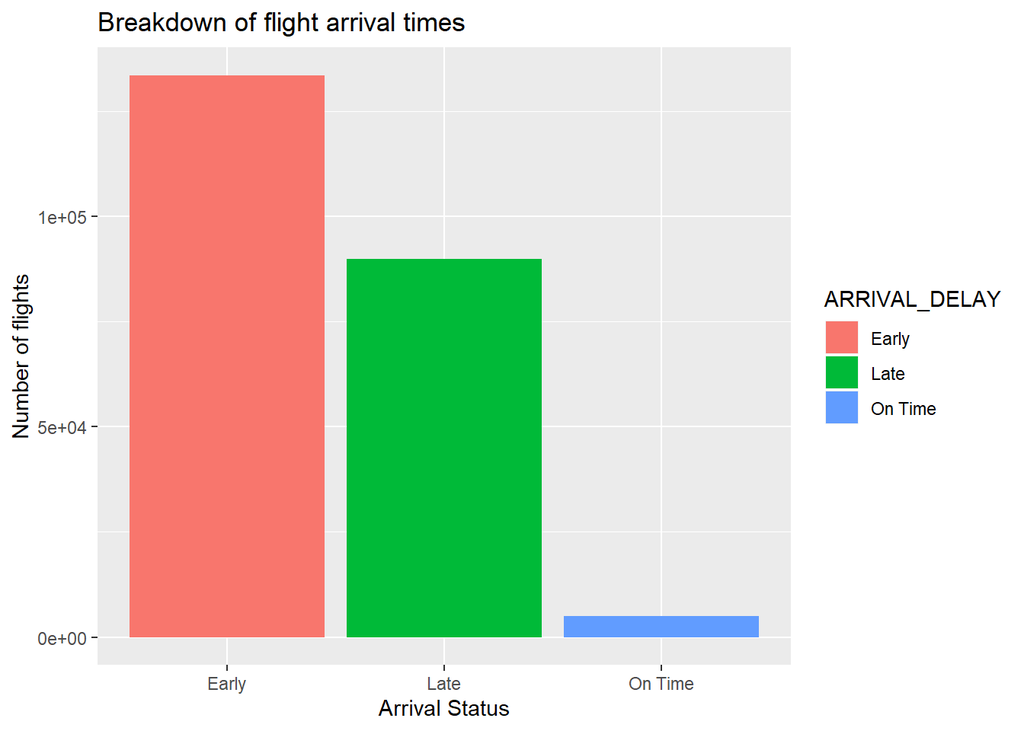

Flights that arrived early were 133,592 out of 231,603 This is very interesting that 58% of flights arrived early!

Flights that were late were 89,909 out of 231,603

Flights that arrived on time were 4,983 out of 231,603

Overall 61% of flights arrived on time!

#### 3.2 A histogram showing the number of flights for various departure delays.

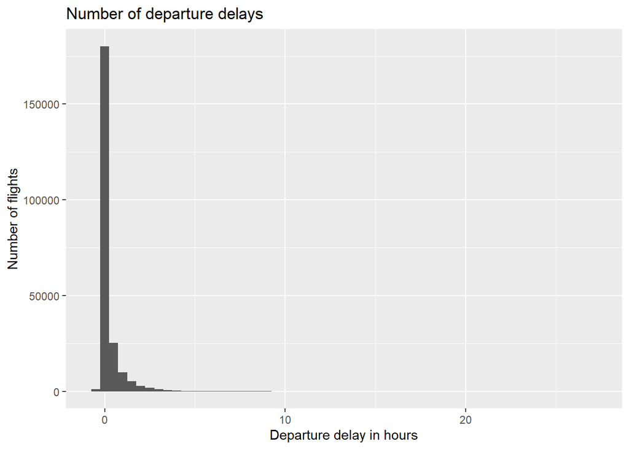

Here we can see that, surprisingly, that most of the flights have only a small delay at depature time.

#### 3.3 The number of flights that were delayed, on time or that didn’t leave by day.

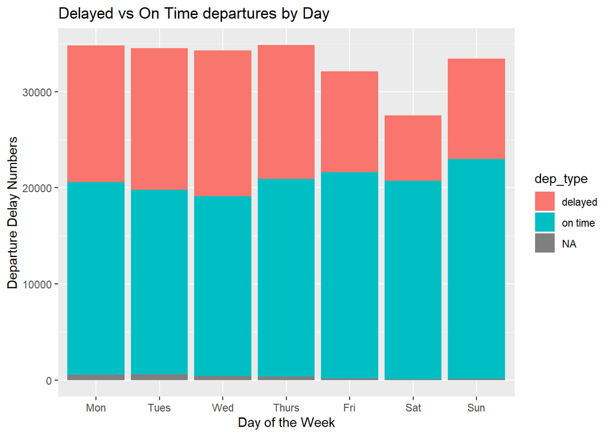

#### 3.4 Number of flights by day of the week and arrival type (delayed, on time or early.

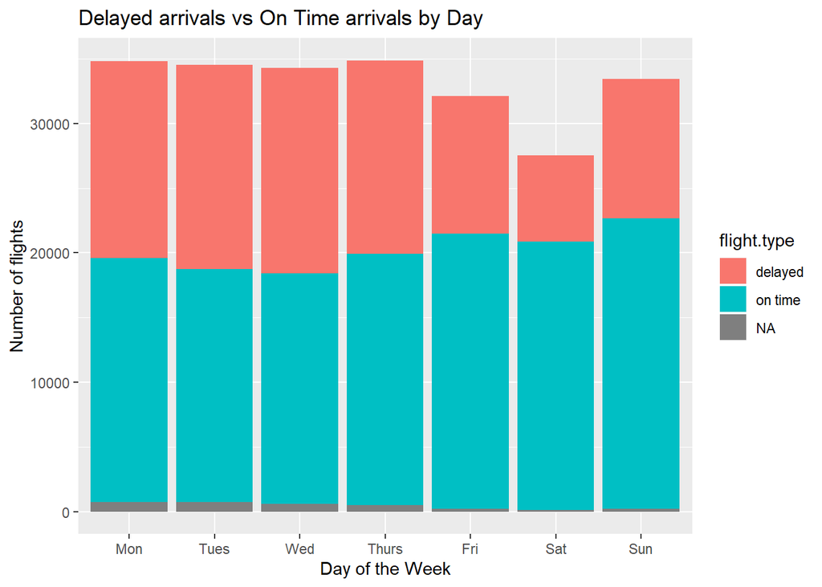

Here we can see the number of flights whose arrival has been delayed by day Saturday seem to be the best day for minimal delays.

#### 3.5 Flights cancelled by day of the week.

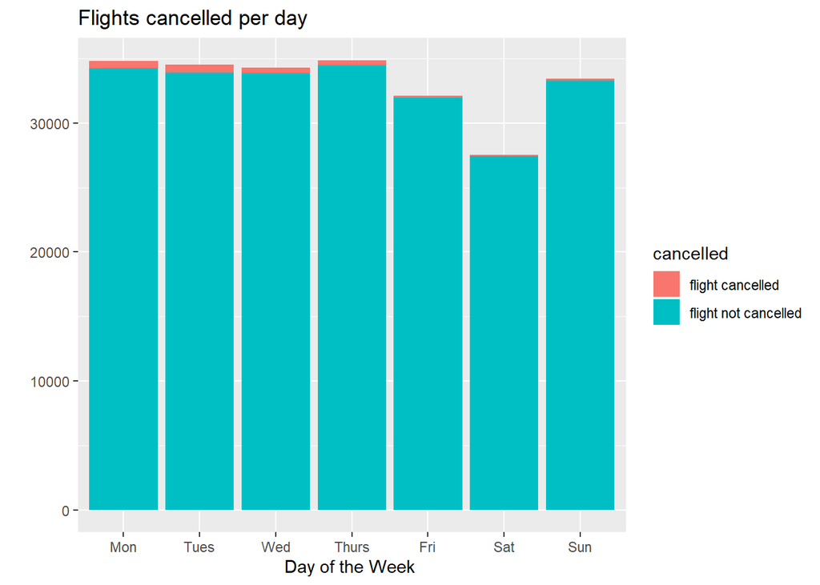

The first four days of the week appear to have the most cancellation of flights again Saturday seems to have the least cancellations.

#### 3.6 1% random sample of flight arrival delay data by days of the week.

```
## geom_smooth: na.rm = FALSE, se = TRUE
## stat_smooth: na.rm = FALSE, se = TRUE, span = 0.1, method = auto, formula = y ~ x
## position_identity
```

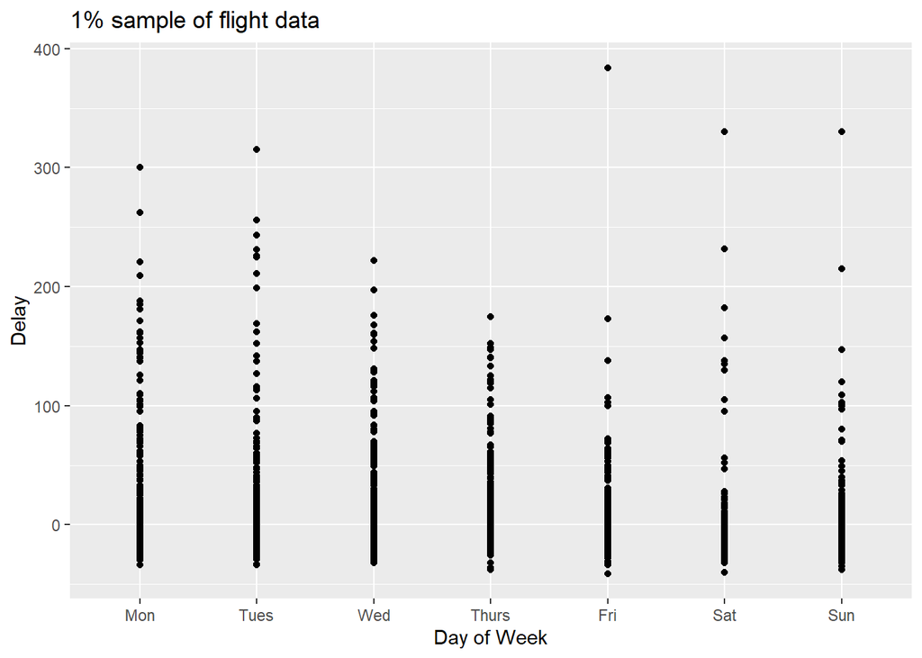

#### 3.7 1% random sample of flight arrival delay data for the two weeks.

```
## geom_smooth: na.rm = FALSE, se = TRUE
## stat_smooth: na.rm = FALSE, se = TRUE, span = 0.1, method = auto, formula = y ~ x
## position_identity
```

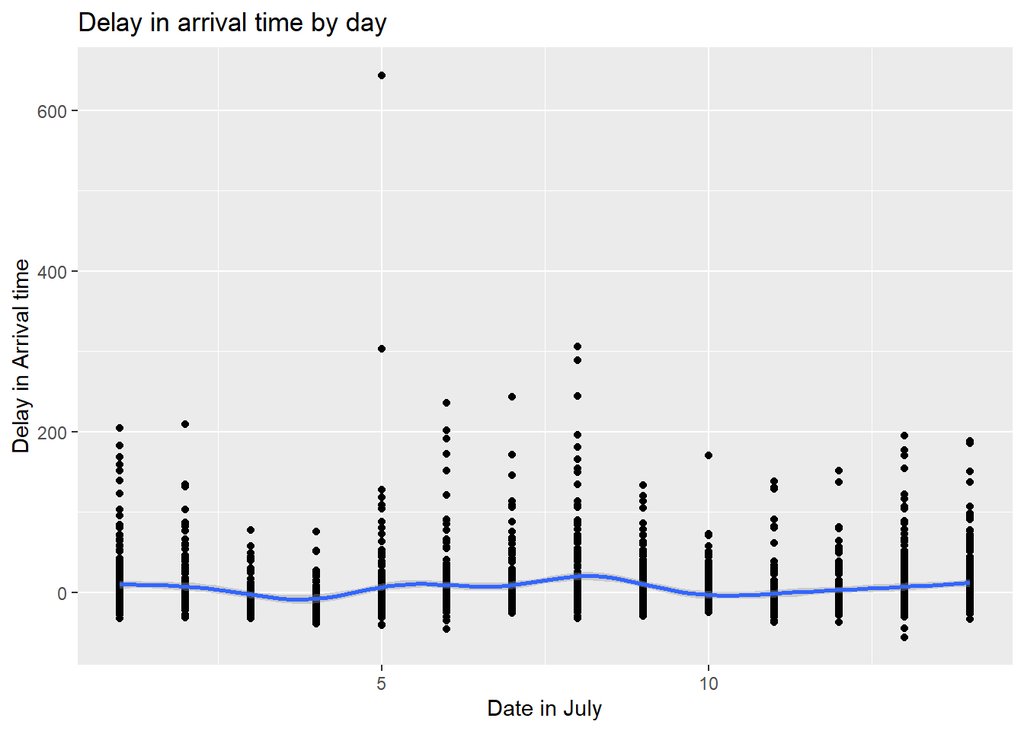

Then to see if there was a difference over the two week period we plotted Date against delay in arrival time, Monday, Tuesday and Wednesday seem to busiest this could possibly be people flying after the 4th of July we ekend?

#### 3.8 Diverted flights per day of the week of all flights that day.

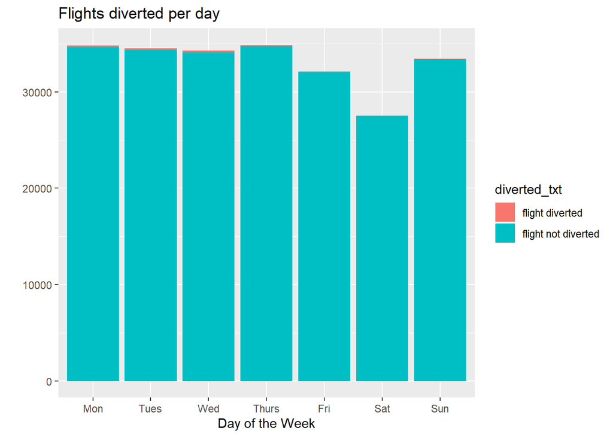

Here we see diverted flights for days of the week, there are some diverted each day, the weekend appears to have less flights diverted.

#### 3.9 Breakdown of flights diverted by day of the week.

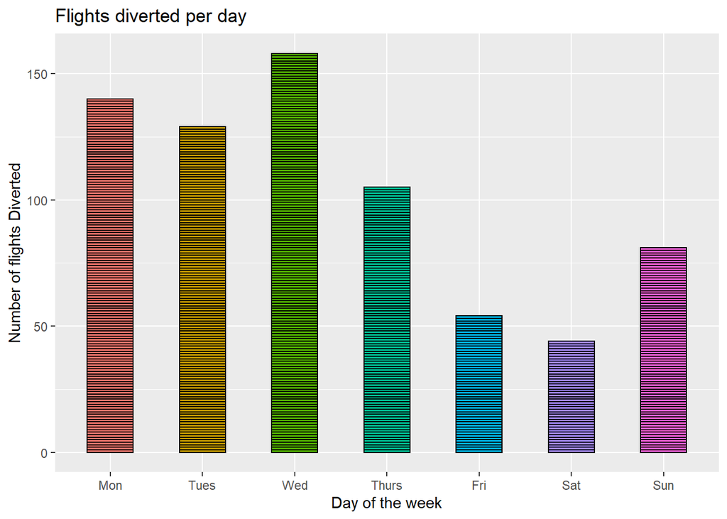

The plot above goes into more detail about the flights diverted. Interestingly, the beginning of the week, has most diversions with Wednesday having the most.

#### 3.10 Plot to see number of flights for each state.

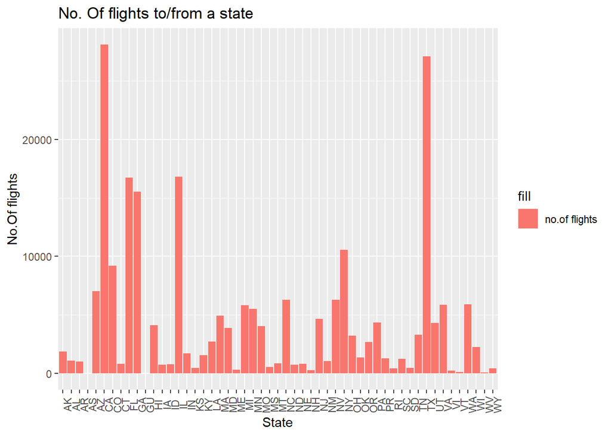

Here we can see two states have the most flights these are California and Texas.

#### 3.11 Percent of flights delayed on for each state.

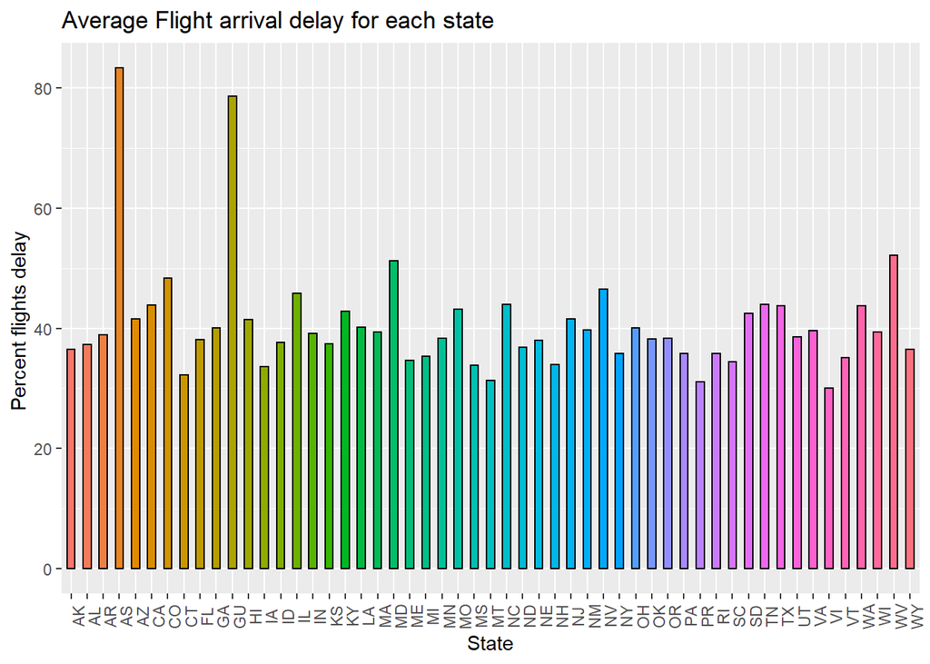

### A. Airlines with the most delays

Here we look at the airline and arrival delay, we removed NA’s as can’t estimate these. We created a column based on whether the flight was delayed (1) or not delayed (0). Then calculating what percentage that airline has late

#### i.Percentage of flights delayed by airline.

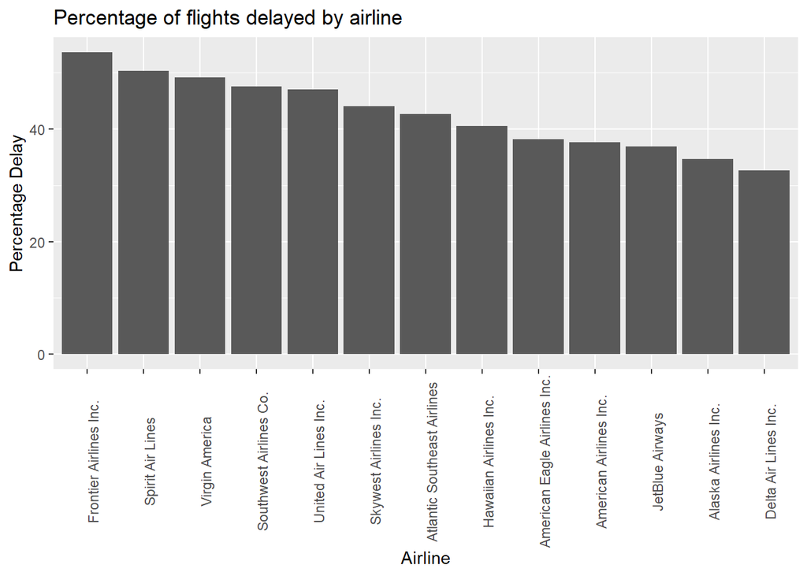

#### ii Average delay per flight by airline

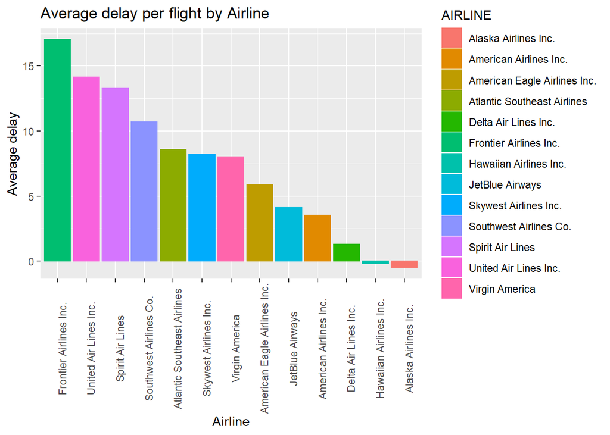

### B. Busiest Routes

Here we created a new column called route made by concatenating the origin and destination airport, and then seeing which had the most flights.

#### i. Plot showing busiest route

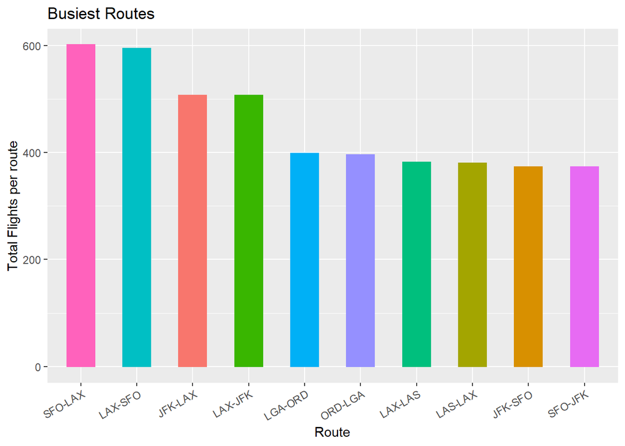

From this we can see that SFO-LAX return , (San Fransico to Los Angeles) was the busiest route, followed by JFK-LAX return , (JFK New York - Los Angeles).

### C. Relationship between distance between airports and flying time

To do this analysis, we used ‘DISTANCE’ for distance between the 2 airports and ‘AIR_TIME’ for the actual flight time.

Below we have calculated the correlation between ‘the distance between airports’ and the flying time.

```
## [1] 0.9914567
```

From this we as it is close to 1 can say there is a strong, positive correlation between distance between airports and flying time.

#### Plot to visualise relationship between aiport distance and flight time

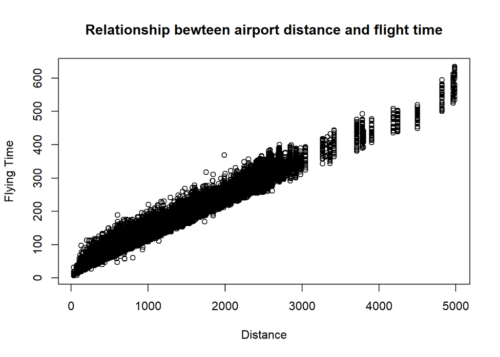

Looking at the plot there appears to be linear relatoinship between the distance between airports and flying time.

#### We can model the data using a linear regression model

Below is the summary data and significance test for linear regression.

```
##
## Call:
## lm(formula = y ~ x)
##
## Residuals:
##     Min      1Q  Median      3Q     Max
## -90.139  -5.169  -1.074   4.146 121.133
##
## Coefficients:
##              Estimate Std. Error t value Pr(>|t|)
## (Intercept) 1.712e+01  3.353e-02   510.7   <2e-16 ***
## x           1.160e-01  3.191e-05  3633.3   <2e-16 ***
## ---
## Signif. codes:  0 '***' 0.001 '**' 0.01 '*' 0.05 '.' 0.1 ' ' 1
##
## Residual standard error: 9.523 on 228482 degrees of freedom
## Multiple R-squared:  0.983,  Adjusted R-squared:  0.983
## F-statistic: 1.32e+07 on 1 and 228482 DF,  p-value: < 2.2e-16
```

From the output we can see the residual errors near the top, there is quite a range between the min and max.

We are then given the Coefficients, here we have the intercept (on the y axis and the slope (‘x’). Then we have the Std. Error, were it is the average estimate coefficient that varies form the actual value. You would want this to be small, which in this case it is. The t value is used to calculate the p value which is were it is < 2e-16 *** which signifes it is significant. This means that we can reject the null hypothsis, that there is not a relationship between distance between airports and flying time. Therefore, we can say that there is a relationship between flying time and the distance between airports.

Then the next section sees the residual standard error. This is the average error of flying time of (9.523) for any given distance. If we look at the R-squared, (denoting a linear relationship, or how well the model fits the data), 1 is completely dependant (i.e the closer to one the better for a linear relationship). Here our model has a value of 0.983 , which supports the idea that their is a linear relationship between flying time and distance between airports, but there are some external factors influencing the model e.g. weather. This may be another avenue for investigation.

The f- value is a statistic that is an overall indictor of whether there is a relationship between the flying times and the distance between airports. The further from 1 the better, so at 1.32e+07 this is a good indictor that the we can reject the null hypothsis and therefore we can again say that there is a relationship between ‘the distance between airports’ and flying time.

It is important that the measures above should not be taken in isolation. We should also examine the residual plots.

#### Residual Plots

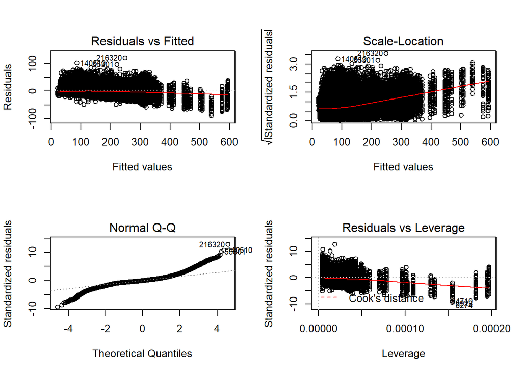

The plots above illustrate the four residual plots from the model.

The first plot shows the Residual vs Fitted. From this we can see that the points are randomly plotted with no pattern on the graph, and points above and below zero. This is a good example of randomness.

The second plot is the Normal Q-Q plot. This tests for normality, (that the residual errors are normally distributed). The plot above shows that the points follow the line for the most part. There is some deviation at the end of the plot. These we think are acceptable.

In the fourth plot, Residuals vs Leverage. We are looking for outliers, especially in the top and bottom right hand corners. Cook’s Distance does not make it onto the chart so all points on chart and within Cook’s distance. This would suggest that there are no outliers in this model.

With this in mind having looked at the coeffiecients, model summary and the residual plots we believe that this model meets with the underlining assumptions of linear regression and is suitbale to use for predicting flying times given a distance.

#### D. Predict flying times

We can use the coefficients from the model to predict flying times. Below are the coefficients for the model

```
## (Intercept)           x
##   17.123064    0.115952
```

Given a distance of 1000 we get a flying time of:

```
## (Intercept)
##     133.075
```

We can also use a predict() function to do the same. By creating a dataframe with the distance we are want a predicted flying time for. We can also set confidence intervals to 95%.

###### So for our test we are looking to predict the time and the 95% confidence intervals for distance of x in this case it is 1000.

```
##       fit      lwr      upr
## 1 133.075 133.0348 133.1153
```

From the output you can see the prediction is again 133.075, but this time there are lower (lwr) and upper (upr) confidence limits. This tells you that the likely location of the actual point.

###### Predict the time with prediction intervals

```
##       fit      lwr      upr
## 1 133.075 114.4093 151.7407
```